# Exploratory Data Analysis - Gapminder Data

### 7.2.3 Hierarchical clustering

This section describes how to perform data analysis using hierarchical clustering method.

*Calculate euclidean distance*

```r
dist_gap <- dist(gapminder_sel_scaled)
```

*Perform the hierarchical clustering using the complete, single, average linkage methods*

```r
hc_gap_complete <- hclust(dist_gap, method="complete")
hc_gap_single <- hclust(dist_gap, method="single")
hc_gap_average <- hclust(dist_gap, method="average")
```

*Plot the 3 dendograms side by side*

```r
par(mfrow = c(1,3))
plot(hc_gap_complete, main = 'Complete Linkage')
plot(hc_gap_single, main = 'Single Linkage')
plot(hc_gap_average, main = 'Average Linkage')
```

[output not shown]

*Create a dendrogram object from the hclust variable*

```r
dend_gap_complete <- as.dendrogram(hc_gap_complete)
```

*Plot the dendrogram*

```r
plot(dend_gap_complete)
```

Note that we have suppressed this plot.

*Color branches by cluster formed from the cut at a height of 2 & plot*

```r
dend_gap_height <- color_branches(dend_gap_complete, h = 2)
```

*Plot the dendrogram with clusters colored below height 2*

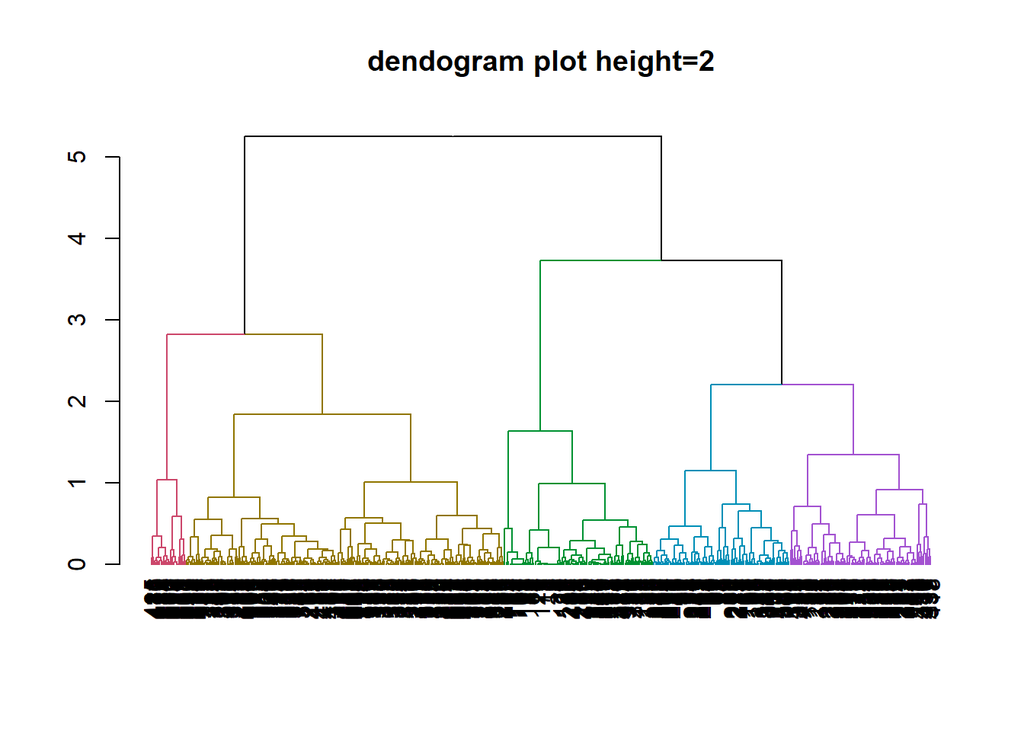

```r
plot(dend_gap_height, main="dendogram plot height=2")
```

This has created 5 clusters based on height=2

*Cutree for height = 2*

```r
clusters_gap_height <- cutree(hc_gap_complete, h=2)
```

*Create a new data frame storing these results*

```r
gap_height_complete <- mutate(gapminder_sel, cluster = clusters_gap_height)
```

*Count the cluster assignments*

```r
count(gap_height_complete, cluster)
```

```
## # A tibble: 5 x 2
##   cluster     n
##     <int> <int>
## 1       1    93
## 2       2    88
## 3       3    85
## 4       4   198
## 5       5    22
```

*Calculate the mean for each category*

```r
gap_height_complete %>%
  group_by(cluster, country) %>%
  summarise(mean(lifeExp),mean(income), n())
```

```
## # A tibble: 22 x 5
## # Groups:   cluster [5]
##    cluster country        `mean(lifeExp)` `mean(income)` `n()`
##      <int> <fct>                    <dbl>          <dbl> <int>
##  1       1 China                     34.6           869.    24
##  2       1 France                    40.0          2522.    10
##  3       1 India                     32.6          1056.    31
##  4       1 Japan                     37.4          1403.    13
##  5       1 United Kingdom            40.4          4044.     6
##  6       1 United States             39.4          3124.     9
##  7       2 China                     56.8           825.    21
##  8       2 France                    50.9          5012.     5
##  9       2 India                     55.6          1755.    41
## 10       2 Japan                     57.1          2990      6
## # ... with 12 more rows
```

*Plot the positions of the lifeExp-Income and color them using their cluster*

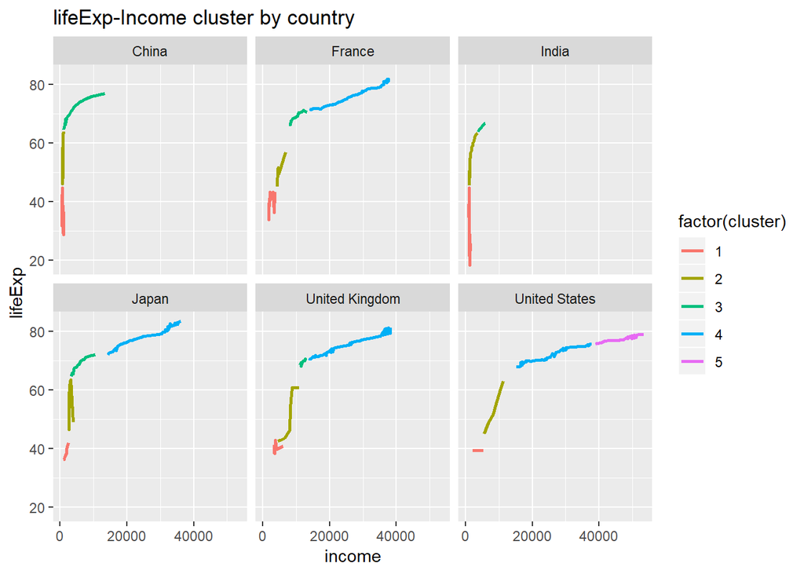

```r
ggplot(gap_height_complete, aes(x = income, y = lifeExp, color = factor(cluster))) +
  geom_line(size=1) +
  facet_wrap(country ~ .) +
  ggtitle("lifeExp-Income cluster by country")
```

As expected, we can see 5 clusters were created for height=2

*Cutree based on clusters instead of height*

```r
clusters_gap6_complete <- cutree(hc_gap_complete, k=6)
```

*Create a new data frame storing these results*

```r
gap_complete <- mutate(gapminder_sel, cluster = clusters_gap6_complete)
```

*Count the cluster assignments*

```r
count(gap_complete, cluster)
```

```
## # A tibble: 6 x 2
##   cluster     n
##     <int> <int>
## 1       1    93
## 2       2    88
## 3       3    85
## 4       4   104
## 5       5    94
## 6       6    22
```

*Calculate the mean for each category*

```r
gap_complete %>%
  group_by(cluster, country) %>%
  summarise(mean(lifeExp), mean(income),n())
```

```
## # A tibble: 26 x 5
## # Groups:   cluster [6]
##    cluster country        `mean(lifeExp)` `mean(income)` `n()`
##      <int> <fct>                    <dbl>          <dbl> <int>
##  1       1 China                     34.6           869.    24
##  2       1 France                    40.0          2522.    10
##  3       1 India                     32.6          1056.    31
##  4       1 Japan                     37.4          1403.    13
##  5       1 United Kingdom            40.4          4044.     6
##  6       1 United States             39.4          3124.     9
##  7       2 China                     56.8           825.    21
##  8       2 France                    50.9          5012.     5
##  9       2 India                     55.6          1755.    41
## 10       2 Japan                     57.1          2990      6
## # ... with 16 more rows
```

*Plot the positions of the lifeExp-Income and color them using their cluster*

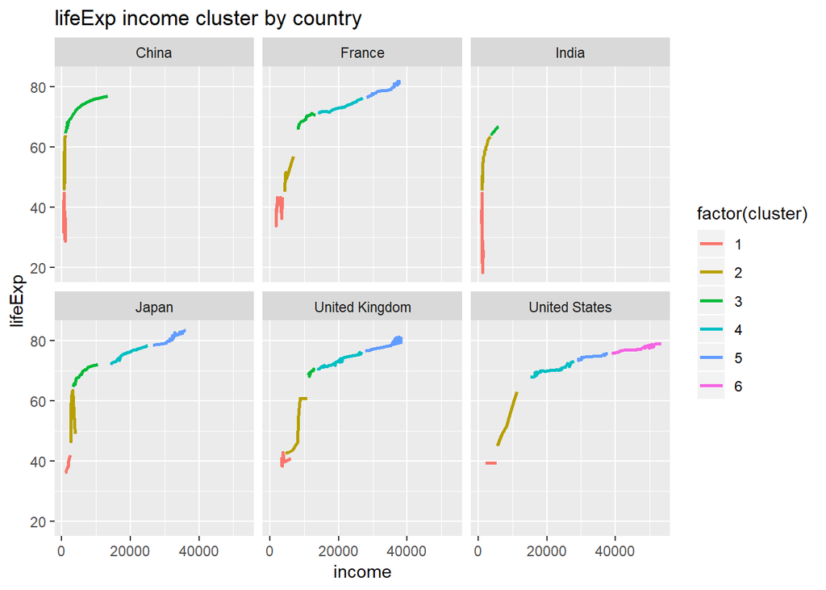

```r
ggplot(gap_complete, aes(x = income, y = lifeExp, color = factor(cluster))) +
  geom_line(size=1) +
  facet_wrap(country ~ .) +
  ggtitle("lifeExp income cluster by country")
```

Visual shows distribution by cluster assignments

#### 7.2.3.1 Compare Hierarchical - Height Vs Cluster Method

Let’s compare the output from hierachical height and cluster clustering methods.

*Compare to Hierarchical Cutree based on Height and # of Clusters*

```r
table(gap_height_complete$cluster, gap_complete$cluster)
```

```
##
##       1   2   3   4   5   6
##   1  93   0   0   0   0   0
##   2   0  88   0   0   0   0
##   3   0   0  85   0   0   0
##   4   0   0   0 104  94   0
##   5   0   0   0   0   0  22
```

Above table shows both height and # clusters have clustered similar way and not seeing much variation. Rows contain the cutree based on height and columns shows the cutree based on number of clusters.

# 8 Conclusion

Overall this analysis shows Life Expectancy have improved dramatically in every country. They remain clearly associated with the income. Life Expectancy is directly correlated with income but shows best-fit with year and region. Population shows steady increase in all regions over the years.

From technical standpoint, we explored the following in R:

1. Installing packages & Loading libraries
2. Reading CSV dataset in R
3. Exploring raw data commands
4. Visualizing raw data - use of histogram, boxplots, density, correlation plots
5. Using baseR plot, ggplot2, custom backgrounds and axis names etc
6. Linear Regression Models - simple, interactions
7. Clustering - K-means, hierarchical
8. Dimensionality Reduction using PCA
9. Use of R Markdown - code chunks, in-line, html, themes, toc, fonts, titles etc
10. Use of github for publishing code & html output

# 9 References

References for performing this exercise includes:

- [DataCamp](https://www.datacamp.com/home)
- [r4ds](https://r4ds.had.co.nz)
- [bookdown](https://bookdown.org/rdpeng/exdata)
- [cran.r-project](https://cran.r-project.org)